# NYPD_shootings

2024-11-02

Question of Interest: Are there any general trend or outliers to NYPD shooting incidents over time and what underlying factors could have contributed to them?

# Datasource

List of every shooting incident that occurred in NYC going back to 2006 through the end of the previous calendar year from data.gov. https://catalog.data.gov/dataset/nypd-shooting-incident-data-historic https://data.cityofnewyork.us/api/views/833y-fsy8/rows.csv?accessType=DOWNLOAD

```r
library(tidyr)
library(magrittr)
library(lubridate)
library(dplyr)
```

```r
library(knitr)
library(ggplot2)
library(forecast)
shootings=read.csv("https://data.cityofnewyork.us/api/views/833y-fsy8/rows.csv?accessType=DOWNLOAD")
kable(head(shootings, 10))
```

| INCIDENT_KEY | OCCUR_DATE | OCCUR_TIME | BORO | LOC_OF_OCCUR_DESC | PRECINCT | JURISDICTION_CODE | LOC_CLASSFCTN_DESC | LOCATION_DESC | STATISTICAL_MURDER_FLAG | PERP_AGE_GROUP | PERP_SEX | PERP_RACE | VIC_AGE_GROUP | VIC_SEX | VIC_RACE | X_COORD_CD | Y_COORD_CD | Latitude | Longitude | Lon_Lat |
| --- | --- | --- | --- | --- | --- | --- | --- | --- | --- | --- | --- | --- | --- | --- | --- | --- | --- | --- | --- | --- |
| 244608249 | 05/05/2022 | 00:10:00 | MANHATTAN | INSIDE | 14 | 0 | COMMERCIAL | VIDEO STORE | true | 25-44 | M | BLACK | 25-44 | M | BLACK | 986050 | 214231.0 | 40.75469 | -73.99350 | POINT (-73.9935 40.754692) |
| 247542571 | 07/04/2022 | 22:20:00 | BRONX | OUTSIDE | 48 | 0 | STREET | (null) | true | (null) | (null) | (null) | 18-24 | M | BLACK | 1016802 | 250581.0 | 40.85440 | -73.88233 | POINT (-73.88233 40.854402) |
| 84967535 | 05/27/2012 | 19:35:00 | QUEENS |  | 103 | 0 |  |  | false |  |  |  | 18-24 | M | BLACK | 1048632 | 198262.0 | 40.71063 | -73.76777 | POINT (-73.76777349199995 40.71063412500007) |
| 202853370 | 09/24/2019 | 21:00:00 | BRONX |  | 42 | 0 |  |  | false | 25-44 | M | UNKNOWN | 25-44 | M | BLACK | 1014493 | 242565.0 | 40.83242 | -73.89071 | POINT (-73.89071440599997 40.832416753000075) |
| 27078636 | 02/25/2007 | 21:00:00 | BROOKLYN |  | 83 | 0 |  |  | false | 25-44 | M | BLACK | 25-44 | M | BLACK | 1009149 | 190104.7 | 40.68844 | -73.91022 | POINT (-73.91021857399994 40.68844345900004) |
| 230311078 | 07/01/2021 | 23:07:00 | MANHATTAN |  | 23 | 2 |  | MULTI DWELL - PUBLIC HOUS | false |  |  |  | 25-44 | M | BLACK | 999061 | 229912.0 | 40.79773 | -73.94651 | POINT (-73.94650786199998 40.79772716600007) |
| 229224142 | 06/07/2021 | 19:55:00 | QUEENS |  | 113 | 0 |  |  | true |  |  |  | 45-64 | M | BLACK | 1042534 | 184647.0 | 40.67331 | -73.78989 | POINT (-73.78988688199998 40.673306465000046) |
| 231246224 | 07/22/2021 | 01:47:00 | BROOKLYN |  | 77 | 0 |  | MULTI DWELL - APT BUILD | false |  |  |  | 25-44 | M | BLACK | 1004507 | 182865.0 | 40.66858 | -73.92698 | POINT (-73.92697993199994 40.66858395700007) |
| 228559720 | 05/22/2021 | 18:39:00 | BRONX |  | 48 | 0 |  |  | false |  |  |  | 18-24 | M | BLACK | 1016391 | 249523.0 | 40.85151 | -73.88382 | POINT (-73.88382239499998 40.851507714000036) |
| 238210279 | 12/22/2021 | 23:17:00 | BRONX |  | 49 | 0 |  |  | true | 25-44 | M | WHITE HISPANIC | 25-44 | M | BLACK | 1021438 | 252793.0 | 40.86046 | -73.86556 | POINT (-73.86556104899995 40.86046306400005) |

```r
summary(shootings)
```

```
##   INCIDENT_KEY        OCCUR_DATE         OCCUR_TIME            BORO
##  Min.   :  9953245   Length:28562       Length:28562       Length:28562
##  1st Qu.: 65439914   Class :character   Class :character   Class :character
##  Median : 92711254   Mode  :character   Mode  :character   Mode  :character
##  Mean   :127405824
##  3rd Qu.:203131993
##  Max.   :279758069
##
##  LOC_OF_OCCUR_DESC     PRECINCT     JURISDICTION_CODE LOC_CLASSFCTN_DESC
##  Length:28562       Min.   :  1.0   Min.   :0.0000    Length:28562
##  Class :character   1st Qu.: 44.0   1st Qu.:0.0000    Class :character
##  Mode  :character   Median : 67.0   Median :0.0000    Mode  :character
##                     Mean   : 65.5   Mean   :0.3219
##                     3rd Qu.: 81.0   3rd Qu.:0.0000
##                     Max.   :123.0   Max.   :2.0000
##                                     NA's   :2
##  LOCATION_DESC      STATISTICAL_MURDER_FLAG PERP_AGE_GROUP
##  Length:28562       Length:28562            Length:28562
##  Class :character   Class :character        Class :character
##  Mode  :character   Mode  :character        Mode  :character
##
##
##
##
##    PERP_SEX          PERP_RACE         VIC_AGE_GROUP        VIC_SEX
##  Length:28562       Length:28562       Length:28562       Length:28562
##  Class :character   Class :character   Class :character   Class :character
##  Mode  :character   Mode  :character   Mode  :character   Mode  :character
##
##
##
##
##    VIC_RACE           X_COORD_CD        Y_COORD_CD        Latitude
##  Length:28562       Min.   : 914928   Min.   :125757   Min.   :40.51
##  Class :character   1st Qu.:1000068   1st Qu.:182912   1st Qu.:40.67
##  Mode  :character   Median :1007772   Median :194901   Median :40.70
##                     Mean   :1009424   Mean   :208380   Mean   :40.74
##                     3rd Qu.:1016807   3rd Qu.:239814   3rd Qu.:40.82
##                     Max.   :1066815   Max.   :271128   Max.   :40.91
##                                                        NA's   :59
##    Longitude        Lon_Lat
##  Min.   :-74.25   Length:28562
##  1st Qu.:-73.94   Class :character
##  Median :-73.92   Mode  :character
##  Mean   :-73.91
##  3rd Qu.:-73.88
##  Max.   :-73.70
##  NA's   :59
```

# Cleaning data

In this section I correct data types, handle nulls and deal with erroneous data. Combined date and time to make them one datetime field. Perp categorical colums age, race, and sex had some empty data points and erroneous (null) string text that I made into nulls. Age group for both perp and had some values that are just numbers that I changed to unknown. I filled (null), na, and blanks in location description fields with NONE to align these columns. I also saw that LOC_CLASSFCTN_DESC had two “other” values combined them to reduce data values in summary for the categorical column. I identified most of these data issues through the summary and looking into distinct values for each categorical column. I identified a few remaining nulls and choose to remove them entirely from the data set. Then finally I made sure to change all categorical columns to factor variables.

```r
#make datetime
shootings<-
  shootings %>%unite("Occur_datetime",c(OCCUR_DATE, OCCUR_TIME),sep=" " )
shootings <- shootings %>%
  mutate(Occur_datetime = mdy_hms(Occur_datetime))

# look into categorical columns
distinct_values <- shootings %>%
  summarise(across(c(BORO,LOC_OF_OCCUR_DESC,PRECINCT,JURISDICTION_CODE,LOC_CLASSFCTN_DESC,LOCATION_DESC,STATISTICAL_MURDER_FLAG,
  PERP_AGE_GROUP,PERP_SEX,PERP_RACE,VIC_AGE_GROUP,VIC_SEX,VIC_RACE), ~ list(unique(as.character(.))))) %>%
  pivot_longer(
     cols = everything(),
     names_to = "column",
     values_to = "distinct_values"
  ) %>%
  unnest(distinct_values) %>%
  arrange(column)
print(distinct_values,n=186)
```

```
## # A tibble: 186 × 2
##     column                  distinct_values
##     <chr>                   <chr>
##   1 BORO                    "MANHATTAN"
##   2 BORO                    "BRONX"
##   3 BORO                    "QUEENS"
##   4 BORO                    "BROOKLYN"
##   5 BORO                    "STATEN ISLAND"
##   6 JURISDICTION_CODE       "0"
##   7 JURISDICTION_CODE       "2"
##   8 JURISDICTION_CODE       "1"
##   9 JURISDICTION_CODE        <NA>
##  10 LOCATION_DESC           "VIDEO STORE"
##  11 LOCATION_DESC           "(null)"
##  12 LOCATION_DESC           ""
```

[output cut: 174 more lines]

```r
#fill blanks,null, and (null) with unknown or U for categorical columns about perp and vic
shootings <- shootings %>%
  mutate(across(c(PERP_AGE_GROUP,PERP_RACE), ~ ifelse(is.na(.) | . == ""| . == "(null)", "UNKNOWN", .)))
shootings <- shootings %>%
  mutate(across(PERP_SEX, ~ ifelse(is.na(.) | . == ""| . == "(null)", "U", .)))

#fill (null),na, and blanks in location descriptions with NONE
shootings <- shootings %>%
  mutate(across(c(LOC_OF_OCCUR_DESC,LOC_CLASSFCTN_DESC,LOCATION_DESC), ~ ifelse(is.na(.) | . == ""| . == "(null)", "NONE", .)))

#deal with errors in categories
# age group has some values that are just numbers change to unknown
shootings <- shootings %>%
  mutate(across(c(PERP_AGE_GROUP,VIC_AGE_GROUP),~ ifelse(grepl("^[0-9]+$", .), "UNKNOWN", .)))
# LOC_CLASSFCTN_DESC has two "other" values combine them
shootings <- shootings %>%
  mutate(across((LOC_CLASSFCTN_DESC), ~ ifelse(.== "OTHER"|.=="(Other)", "(Other)", .)))

#change categorical columns to factor
shootings <- shootings %>%
  mutate(across(c(BORO,PRECINCT, JURISDICTION_CODE, LOC_OF_OCCUR_DESC, LOC_CLASSFCTN_DESC,LOCATION_DESC,PERP_AGE_GROUP,PERP_SEX,PERP_RACE,VIC_AGE_GROUP,VIC_SEX, VIC_RACE,STATISTICAL_MURDER_FLAG), as.factor))

#get rid of remaining NAs 59 in lat and long, and 2 in Jurisdiction code
shootings <- shootings %>%filter(!is.na(Latitude)&!is.na(Longitude)&!is.na(JURISDICTION_CODE))
```

# Output after cleaning

```r
kable(head(shootings, 10))
```

| INCIDENT_KEY | Occur_datetime | BORO | LOC_OF_OCCUR_DESC | PRECINCT | JURISDICTION_CODE | LOC_CLASSFCTN_DESC | LOCATION_DESC | STATISTICAL_MURDER_FLAG | PERP_AGE_GROUP | PERP_SEX | PERP_RACE | VIC_AGE_GROUP | VIC_SEX | VIC_RACE | X_COORD_CD | Y_COORD_CD | Latitude | Longitude | Lon_Lat |
| --- | --- | --- | --- | --- | --- | --- | --- | --- | --- | --- | --- | --- | --- | --- | --- | --- | --- | --- | --- |
| 244608249 | 2022-05-05 00:10:00 | MANHATTAN | INSIDE | 14 | 0 | COMMERCIAL | VIDEO STORE | true | 25-44 | M | BLACK | 25-44 | M | BLACK | 986050 | 214231.0 | 40.75469 | -73.99350 | POINT (-73.9935 40.754692) |
| 247542571 | 2022-07-04 22:20:00 | BRONX | OUTSIDE | 48 | 0 | STREET | NONE | true | UNKNOWN | U | UNKNOWN | 18-24 | M | BLACK | 1016802 | 250581.0 | 40.85440 | -73.88233 | POINT (-73.88233 40.854402) |
| 84967535 | 2012-05-27 19:35:00 | QUEENS | NONE | 103 | 0 | NONE | NONE | false | UNKNOWN | U | UNKNOWN | 18-24 | M | BLACK | 1048632 | 198262.0 | 40.71063 | -73.76777 | POINT (-73.76777349199995 40.71063412500007) |
| 202853370 | 2019-09-24 21:00:00 | BRONX | NONE | 42 | 0 | NONE | NONE | false | 25-44 | M | UNKNOWN | 25-44 | M | BLACK | 1014493 | 242565.0 | 40.83242 | -73.89071 | POINT (-73.89071440599997 40.832416753000075) |
| 27078636 | 2007-02-25 21:00:00 | BROOKLYN | NONE | 83 | 0 | NONE | NONE | false | 25-44 | M | BLACK | 25-44 | M | BLACK | 1009149 | 190104.7 | 40.68844 | -73.91022 | POINT (-73.91021857399994 40.68844345900004) |
| 230311078 | 2021-07-01 23:07:00 | MANHATTAN | NONE | 23 | 2 | NONE | MULTI DWELL - PUBLIC HOUS | false | UNKNOWN | U | UNKNOWN | 25-44 | M | BLACK | 999061 | 229912.0 | 40.79773 | -73.94651 | POINT (-73.94650786199998 40.79772716600007) |
| 229224142 | 2021-06-07 19:55:00 | QUEENS | NONE | 113 | 0 | NONE | NONE | true | UNKNOWN | U | UNKNOWN | 45-64 | M | BLACK | 1042534 | 184647.0 | 40.67331 | -73.78989 | POINT (-73.78988688199998 40.673306465000046) |
| 231246224 | 2021-07-22 01:47:00 | BROOKLYN | NONE | 77 | 0 | NONE | MULTI DWELL - APT BUILD | false | UNKNOWN | U | UNKNOWN | 25-44 | M | BLACK | 1004507 | 182865.0 | 40.66858 | -73.92698 | POINT (-73.92697993199994 40.66858395700007) |
| 228559720 | 2021-05-22 18:39:00 | BRONX | NONE | 48 | 0 | NONE | NONE | false | UNKNOWN | U | UNKNOWN | 18-24 | M | BLACK | 1016391 | 249523.0 | 40.85151 | -73.88382 | POINT (-73.88382239499998 40.851507714000036) |
| 238210279 | 2021-12-22 23:17:00 | BRONX | NONE | 49 | 0 | NONE | NONE | true | 25-44 | M | WHITE HISPANIC | 25-44 | M | BLACK | 1021438 | 252793.0 | 40.86046 | -73.86556 | POINT (-73.86556104899995 40.86046306400005) |

```r
summary(shootings)
```

```
##   INCIDENT_KEY       Occur_datetime                              BORO
##  Min.   :  9953245   Min.   :2006-01-01 02:00:00.00   BRONX        : 8363
##  1st Qu.: 65276038   1st Qu.:2009-08-31 00:50:00.00   BROOKLYN     :11331
##  Median : 92550741   Median :2013-09-09 05:26:00.00   MANHATTAN    : 3745
##  Mean   :127118170   Mean   :2014-06-01 02:56:39.49   QUEENS       : 4262
##  3rd Qu.:202504685   3rd Qu.:2019-09-16 00:20:00.00   STATEN ISLAND:  800
##  Max.   :279758069   Max.   :2023-12-29 21:22:00.00
##
##  LOC_OF_OCCUR_DESC    PRECINCT     JURISDICTION_CODE  LOC_CLASSFCTN_DESC
##  INSIDE :  458     75     : 1626   0:23865           NONE      :25596
##  NONE   :25594     73     : 1498   1:   80           STREET    : 1842
##  OUTSIDE: 2449     67     : 1259   2: 4556           HOUSING   :  459
##                    44     : 1076                     DWELLING  :  241
##                    79     : 1045                     COMMERCIAL:  207
##                    47     : 1006                     (Other)   :   53
##                    (Other):20991                     (Other)   :  103
##                    LOCATION_DESC   STATISTICAL_MURDER_FLAG PERP_AGE_GROUP
##  NONE                     :16819   false:22979             <18    : 1673
##  MULTI DWELL - PUBLIC HOUS: 5006   true : 5522             18-24  : 6425
##  MULTI DWELL - APT BUILD  : 2960                           25-44  : 6032
##  PVT HOUSE                :  983                           45-64  :  697
##  GROCERY/BODEGA           :  750                           65+    :   65
##  BAR/NIGHT CLUB           :  668                           UNKNOWN:13609
##  (Other)                  : 1315
##  PERP_SEX                           PERP_RACE     VIC_AGE_GROUP   VIC_SEX
##  F:  443   AMERICAN INDIAN/ALASKAN NATIVE:    2   <18    : 2946   F: 2753
##  M:16134   ASIAN / PACIFIC ISLANDER      :  169   18-24  :10362   M:25736
##  U:11924   BLACK                         :11880   25-44  :12945   U:   12
##            BLACK HISPANIC                : 1388   45-64  : 1978
##            UNKNOWN                       :12262   65+    :  205
##            WHITE                         :  298   UNKNOWN:   65
##            WHITE HISPANIC                : 2502
##                            VIC_RACE       X_COORD_CD        Y_COORD_CD
##  AMERICAN INDIAN/ALASKAN NATIVE:   11   Min.   : 914928   Min.   :125757
##  ASIAN / PACIFIC ISLANDER      :  440   1st Qu.:1000068   1st Qu.:182905
##  BLACK                         :20201   Median :1007776   Median :194872
##  BLACK HISPANIC                : 2787   Mean   :1009438   Mean   :208375
##  UNKNOWN                       :   70   3rd Qu.:1016807   3rd Qu.:239814
##  WHITE                         :  728   Max.   :1066815   Max.   :271128
##  WHITE HISPANIC                : 4264
##     Latitude       Longitude        Lon_Lat
##  Min.   :40.51   Min.   :-74.25   Length:28501
##  1st Qu.:40.67   1st Qu.:-73.94   Class :character
##  Median :40.70   Median :-73.92   Mode  :character
##  Mean   :40.74   Mean   :-73.91
##  3rd Qu.:40.82   3rd Qu.:-73.88
##  Max.   :40.91   Max.   :-73.70
##
```

Roughly about half the data set is missing a perp age group. All the location descriptions also have a lot of missing values. These values are still included under either unknown or none depending on the category. An analysis factoring these columns will need to take this under consideration for potential issues. For example, not knowing how that data is populated some locations may be more likely to have descriptions than others which can lead to incorrect conclusions.

# Visualizations

The first visualization I output was solely NYPD shootings by year and then I output by borough to see if there was any noticeable trends. I noticed a large spike in 2020 so decided look closer and see a trend by month. A significant spike can be seen from may 2020 to oct 2020 and some overall seasonal trends for shootings seem to appear for entire data set. I then choose to look the latest 5 years of the data set to get a closer look at the 2020 increase specifically and then broke it up by borough. This increase can also be seen in each borough with the Bronx and Brooklyn having the largest increase. A seasonal trend can also be seen in the monthly data with spikes in what appears to be every summer.

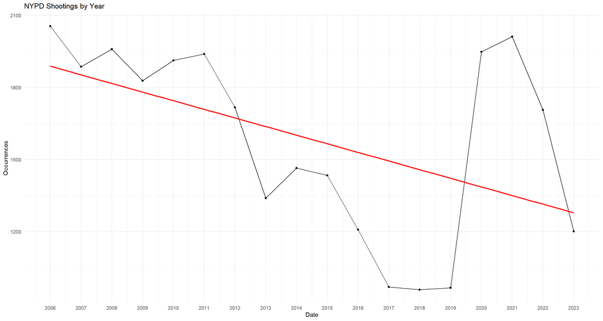

```r
#Looking into data over time
#NYPD shootings over years
grouped_df <- shootings %>%
  mutate(year = year(Occur_datetime)) %>%
  group_by(year) %>%
  summarise(occurrences = n())
ggplot(grouped_df, aes(x = year, y = occurrences)) +
  geom_line() +
  geom_point() +
  labs(title = "NYPD Shootings by Year", x = "Date", y = "Occurrences") +
  theme_minimal()+
  scale_x_continuous(breaks = seq(min(grouped_df$year),max(grouped_df$year), by = 1))+
  geom_smooth(method = "lm", color = "red", se = FALSE)
```

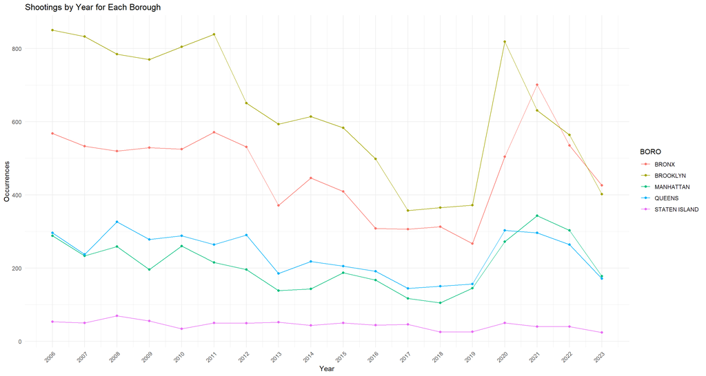

```r
# NYPD shootings by Boro over years
boro_grouped_df <- shootings %>%
  mutate(year = year(Occur_datetime)) %>%
  group_by(BORO, year) %>%
  summarise(occurrences = n(), .groups = 'drop')
ggplot(boro_grouped_df, aes(x = year, y = occurrences, color = BORO, group = BORO)) +
  geom_line() +
  geom_point() +
  labs(title = "Shootings by Year for Each Borough",
       x = "Year", y = "Occurrences") +
  theme_minimal() +
  scale_x_continuous(
    breaks = seq(min(boro_grouped_df$year), max(boro_grouped_df$year), by = 1)
  ) +
  theme(axis.text.x = element_text(angle = 45, hjust = 1))
```

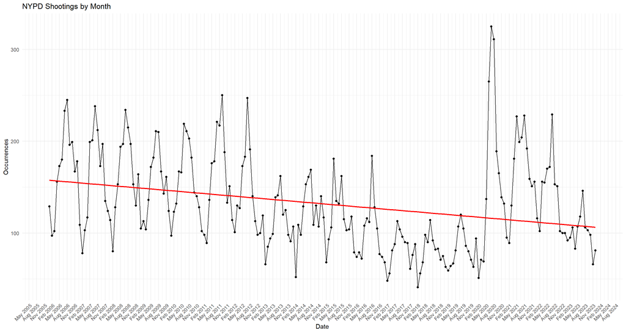

```r
grouped_my_df <- shootings %>%
  mutate(monthyear = floor_date(Occur_datetime, "month")) %>%
  group_by(monthyear) %>%
  summarise(occurrences = n(), .groups = 'drop') %>%
  mutate(monthyear = as.Date(monthyear))
ggplot(grouped_my_df, aes(x = monthyear, y = occurrences)) +
  geom_line() +
  geom_point() +
  labs(title = "NYPD Shootings by Month", x = "Date", y = "Occurrences") +
  theme_minimal()+
  scale_x_date(
    date_breaks = "3 month",
    date_labels = "%b %Y"
  ) +
  theme(axis.text.x = element_text(angle = 45, hjust = 1)) +
  geom_smooth(method = "lm", color = "red", se = FALSE)
```

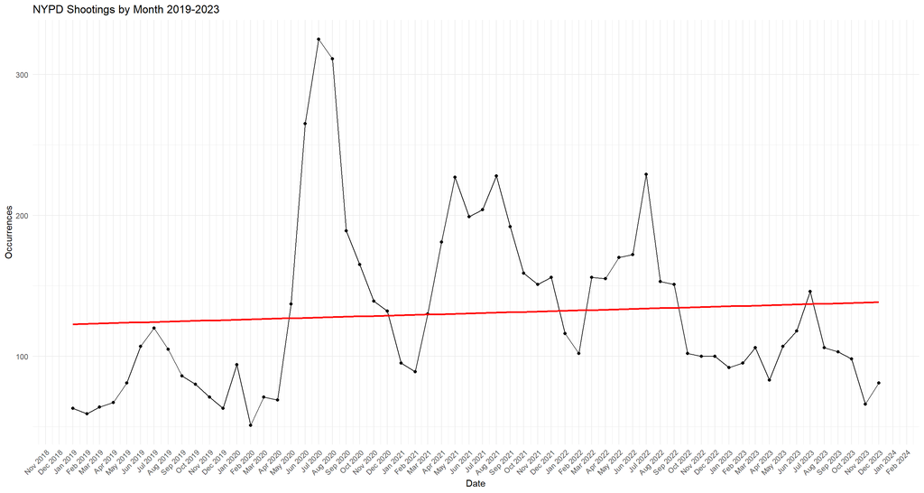

```r
#looking into last 5 years of data set to investigate increase in 2020-2022
date_filtered_df <- shootings %>%
  filter(year(Occur_datetime) >= (2019))

grouped_df <- date_filtered_df %>%
  mutate(monthyear = floor_date(Occur_datetime, "month")) %>%
  group_by(monthyear) %>%
  summarise(occurrences = n()) %>%
  mutate(monthyear = as.Date(monthyear))
ggplot(grouped_df, aes(x = monthyear, y = occurrences)) +
  geom_line() +
  geom_point() +
  labs(title = "NYPD Shootings by Month 2019-2023", x = "Date", y = "Occurrences") +
  theme_minimal()+
  scale_x_date(
    date_breaks = "1 month",
    date_labels = "%b %Y"
  ) +
  theme(axis.text.x = element_text(angle = 45, hjust = 1)) +
  geom_smooth(method = "lm", color = "red", se = FALSE)
```

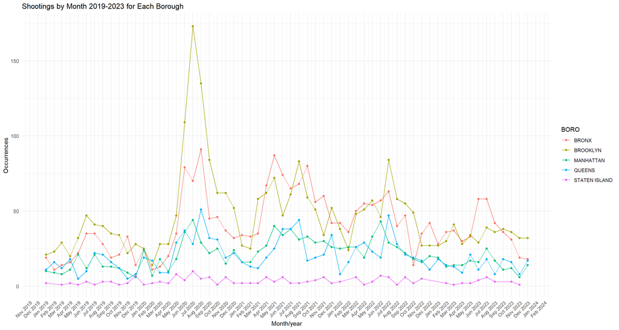

```r
#by boro
boro_grouped_df <- date_filtered_df %>%
  mutate(monthyear = floor_date(Occur_datetime, "month")) %>%
  group_by(BORO, monthyear) %>%
  summarise(occurrences = n(), .groups = 'drop') %>%
  mutate(monthyear = as.Date(monthyear))
ggplot(boro_grouped_df, aes(x = monthyear, y = occurrences, color = BORO, group = BORO)) +
  geom_line() +
  geom_point() +
  labs(title = "Shootings by Month 2019-2023 for Each Borough",
       x = "Month/year", y = "Occurrences") +
  theme_minimal() +
  scale_x_date(
    date_breaks = "1 month",
    date_labels = "%b %Y"
  ) +
  theme(axis.text.x = element_text(angle = 45, hjust = 1))
```

# Analysis/Models

```r
#linear model year against occurrences
date_unfiltered_df <- shootings %>%
  mutate(year = as.numeric(year(Occur_datetime)))%>%
  group_by(year) %>%
  summarise(occurrences = n(), .groups = "drop")
lm_model <- lm(occurrences ~ year, data = date_unfiltered_df)
summary(lm_model)
```

```
##
## Call:
## lm(formula = occurrences ~ year, data = date_unfiltered_df)
##
## Residuals:
##     Min      1Q  Median      3Q     Max
## -523.71 -257.98   38.75  167.06  660.79
##
## Coefficients:
##             Estimate Std. Error t value Pr(>|t|)
## (Intercept) 73849.68   32410.18   2.279   0.0368 *
## year          -35.87      16.09  -2.230   0.0404 *
## ---
## Signif. codes:  0 '***' 0.001 '**' 0.01 '*' 0.05 '.' 0.1 ' ' 1
##
## Residual standard error: 354.1 on 16 degrees of freedom
## Multiple R-squared:  0.2371, Adjusted R-squared:  0.1894
## F-statistic: 4.972 on 1 and 16 DF,  p-value: 0.04044
```

```r
correlation <- cor(date_unfiltered_df$year, date_unfiltered_df$occurrences)
print(correlation)
```

```
## [1] -0.4868982
```

```r
#linear model year against occurrences 2006-2019
date_unfiltered_df <- shootings %>%
  mutate(year = as.numeric(year(Occur_datetime)))%>%
  group_by(year) %>%
  filter(year<2019) %>%
  summarise(occurrences = n(), .groups = "drop")
lm_model <- lm(occurrences ~ year, data = date_unfiltered_df)
summary(lm_model)
```

```
##
## Call:
## lm(formula = occurrences ~ year, data = date_unfiltered_df)
##
## Residuals:
##     Min      1Q  Median      3Q     Max
## -166.67  -90.22  -11.72  121.72  256.53
##
## Coefficients:
##              Estimate Std. Error t value Pr(>|t|)
## (Intercept) 187799.42   20720.02   9.064 1.96e-06 ***
## year           -92.55      10.30  -8.987 2.13e-06 ***
## ---
## Signif. codes:  0 '***' 0.001 '**' 0.01 '*' 0.05 '.' 0.1 ' ' 1
##
## Residual standard error: 138.9 on 11 degrees of freedom
## Multiple R-squared:  0.8801, Adjusted R-squared:  0.8692
## F-statistic: 80.77 on 1 and 11 DF,  p-value: 2.126e-06
```

```r
correlation <- cor(date_unfiltered_df$year, date_unfiltered_df$occurrences)
print(correlation)
```

```
## [1] -0.9381519
```

```r
#linear model year against occurrences last 5 years
m_date_filtered_df <- date_filtered_df %>%
  mutate(year = as.numeric(year(Occur_datetime)))%>%
  group_by(year) %>%
  summarise(occurrences = n(), .groups = "drop")
lm_model <- lm(occurrences ~ year, data = m_date_filtered_df)
summary(lm_model)
```

```
##
## Call:
## lm(formula = occurrences ~ year, data = m_date_filtered_df)
##
## Residuals:
##      1      2      3      4      5
## -554.8  404.4  444.6  116.8 -411.0
##
## Coefficients:
##             Estimate Std. Error t value Pr(>|t|)
## (Intercept) -44512.4   340500.1  -0.131    0.904
## year            22.8      168.5   0.135    0.901
##
## Residual standard error: 532.8 on 3 degrees of freedom
## Multiple R-squared:  0.006067,   Adjusted R-squared:  -0.3252
## F-statistic: 0.01831 on 1 and 3 DF,  p-value: 0.9009
```

```r
correlation <- cor(m_date_filtered_df$year, m_date_filtered_df$occurrences)
print(correlation)
```

```
## [1] 0.07789362
```

```r
#filtering out last 5 years looking into ets model to get info for potential forecasting in the future.
ts_data <- ts(date_unfiltered_df$occurrences, start=c(2006, 1), frequency=12)
ets_model <- ets(ts_data)
summary(ets_model)
```

```
## ETS(A,N,N)
##
## Call:
## ets(y = ts_data)
##
##   Smoothing parameters:
##     alpha = 0.9999
##
##   Initial states:
##     l = 2054.9684
##
##   sigma:  184.7369
##
##      AIC     AICc      BIC
## 172.8649 175.5316 174.5597
##
## Training set error measures:
##                     ME     RMSE      MAE       MPE     MAPE      MASE
## Training set -84.39053 169.9332 131.9247 -6.602539 9.379194 0.1202595
##                    ACF1
## Training set -0.1377345
```

```r
#using all data for ets model to get info for potential forecasting in the future.
ts_data <- ts(grouped_my_df$occurrences, start=c(2006, 1), frequency=12)
ets_model <- ets(ts_data)
summary(ets_model)
```

```
## ETS(M,N,M)
##
## Call:
## ets(y = ts_data)
##
##   Smoothing parameters:
##     alpha = 0.491
##     gamma = 1e-04
##
##   Initial states:
##     l = 162.6715
##     s = 0.8502 0.8261 0.9843 1.0989 1.3987 1.4245
##            1.2954 1.1164 0.8585 0.7556 0.6123 0.7793
##
##   sigma:  0.1831
##
##      AIC     AICc      BIC
## 2525.219 2527.619 2575.848
##
## Training set error measures:
##                      ME     RMSE      MAE      MPE     MAPE     MASE      ACF1
## Training set -0.5149677 23.93109 17.12473 -2.66561 13.30445 0.597988 0.1394961
```

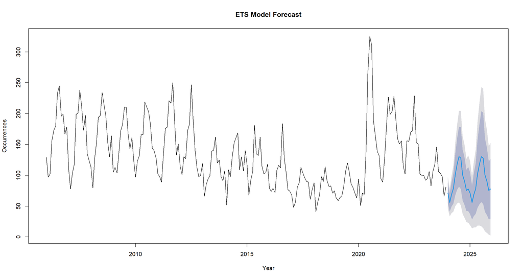

```r
plot(forecast(ets_model), main="ETS Model Forecast", xlab="Year", ylab="Occurrences")
```

# Conclusion

These findings bring up more questions such as were other major US cities seeing this increase in shootings that correlate with COVID? Why the Bronx and Brooklyn increased so significantly compared to other boroughs? Another important question would be why shootings remained rather high in 2021 and 2022, it is worth investigating this time frame to see if the increase would still correlate with the impacts of COVID or if it is something else?

Regarding bias, I believe my analysis has the most bias. Regarding the data set I don’t have too much knowledge of New York and data on shootings is something I have never really considered looking into before. My bias comes in when seeing the data spike in 2020, my immediate guess was COVID was the a big factor for it. That may have caused bias so I attempted to mitigate it by showing 5 years of data by month along with 2020. This shows that there are other noticeable spikes like in mid 2021 that cannot be as easily explained by the COVID. Also, note that COVID was just one of the factors that could have contributed to a rise in shootings, another potential factor could be the unrest and protests regarding George Floyd and there could be many more factors.